# Logistic regression

```python
import pandas as pd
import numpy as np
import matplotlib.pyplot as plt
import seaborn as sns
from sklearn.linear_model import LogisticRegression
from sklearn.metrics import confusion_matrix,recall_score,precision_score,f1_score
from sklearn.preprocessing import StandardScaler
from sklearn.preprocessing import LabelEncoder
from sklearn.model_selection import train_test_split
```

```python
df =pd.read_csv(r'/Users/simranjitkaur/Documents/input file related to python/heart.csv')
df
```

|  | Age | Sex | ChestPainType | RestingBP | Cholesterol | FastingBS | RestingECG | MaxHR | ExerciseAngina | Oldpeak | ST_Slope | HeartDisease |
| --- | --- | --- | --- | --- | --- | --- | --- | --- | --- | --- | --- | --- |
| 0 | 40 | M | ATA | 140 | 289 | 0 | Normal | 172 | N | 0.0 | Up | 0 |
| 1 | 49 | F | NAP | 160 | 180 | 0 | Normal | 156 | N | 1.0 | Flat | 1 |
| 2 | 37 | M | ATA | 130 | 283 | 0 | ST | 98 | N | 0.0 | Up | 0 |
| 3 | 48 | F | ASY | 138 | 214 | 0 | Normal | 108 | Y | 1.5 | Flat | 1 |
| 4 | 54 | M | NAP | 150 | 195 | 0 | Normal | 122 | N | 0.0 | Up | 0 |
| ... | ... | ... | ... | ... | ... | ... | ... | ... | ... | ... | ... | ... |
| 913 | 45 | M | TA | 110 | 264 | 0 | Normal | 132 | N | 1.2 | Flat | 1 |
| 914 | 68 | M | ASY | 144 | 193 | 1 | Normal | 141 | N | 3.4 | Flat | 1 |
| 915 | 57 | M | ASY | 130 | 131 | 0 | Normal | 115 | Y | 1.2 | Flat | 1 |
| 916 | 57 | F | ATA | 130 | 236 | 0 | LVH | 174 | N | 0.0 | Flat | 1 |
| 917 | 38 | M | NAP | 138 | 175 | 0 | Normal | 173 | N | 0.0 | Up | 0 |

918 rows × 12 columns

## Performing EDA

```python
df.shape
```

```
(918, 12)
```

```python
df.info()
```

```
<class 'pandas.core.frame.DataFrame'>
RangeIndex: 918 entries, 0 to 917
Data columns (total 12 columns):
 #   Column          Non-Null Count  Dtype
---  ------          --------------  -----
 0   Age             918 non-null    int64
 1   Sex             918 non-null    object
 2   ChestPainType   918 non-null    object
 3   RestingBP       918 non-null    int64
 4   Cholesterol     918 non-null    int64
 5   FastingBS       918 non-null    int64
 6   RestingECG      918 non-null    object
 7   MaxHR           918 non-null    int64
 8   ExerciseAngina  918 non-null    object
 9   Oldpeak         918 non-null    float64
 10  ST_Slope        918 non-null    object
 11  HeartDisease    918 non-null    int64
dtypes: float64(1), int64(6), object(5)
memory usage: 86.2+ KB
```

```python
df.keys()
```

```
Index(['Age', 'Sex', 'ChestPainType', 'RestingBP', 'Cholesterol', 'FastingBS',
       'RestingECG', 'MaxHR', 'ExerciseAngina', 'Oldpeak', 'ST_Slope',
       'HeartDisease'],
      dtype='object')
```

```python
encode = LabelEncoder()
df['Gender']= encode.fit_transform(df['Sex'])
df['Chest_Pain_Type']= encode.fit_transform(df['ChestPainType'])
df['Resting_ECG']= encode.fit_transform(df['RestingECG'])
df['Exercise_Angina ']= encode.fit_transform(df['ExerciseAngina'])
df['ST_Slope_en']= encode.fit_transform(df['ST_Slope'])
```

```python
df.drop(columns=['Sex', 'ChestPainType','RestingECG','ExerciseAngina','ST_Slope'],axis=0,inplace =True)
df
```

|  | Age | RestingBP | Cholesterol | FastingBS | MaxHR | Oldpeak | HeartDisease | Gender | Chest_Pain_Type | Resting_ECG | Exercise_Angina | ST_Slope_en |
| --- | --- | --- | --- | --- | --- | --- | --- | --- | --- | --- | --- | --- |
| 0 | 40 | 140 | 289 | 0 | 172 | 0.0 | 0 | 1 | 1 | 1 | 0 | 2 |
| 1 | 49 | 160 | 180 | 0 | 156 | 1.0 | 1 | 0 | 2 | 1 | 0 | 1 |
| 2 | 37 | 130 | 283 | 0 | 98 | 0.0 | 0 | 1 | 1 | 2 | 0 | 2 |
| 3 | 48 | 138 | 214 | 0 | 108 | 1.5 | 1 | 0 | 0 | 1 | 1 | 1 |
| 4 | 54 | 150 | 195 | 0 | 122 | 0.0 | 0 | 1 | 2 | 1 | 0 | 2 |
| ... | ... | ... | ... | ... | ... | ... | ... | ... | ... | ... | ... | ... |
| 913 | 45 | 110 | 264 | 0 | 132 | 1.2 | 1 | 1 | 3 | 1 | 0 | 1 |
| 914 | 68 | 144 | 193 | 1 | 141 | 3.4 | 1 | 1 | 0 | 1 | 0 | 1 |
| 915 | 57 | 130 | 131 | 0 | 115 | 1.2 | 1 | 1 | 0 | 1 | 1 | 1 |
| 916 | 57 | 130 | 236 | 0 | 174 | 0.0 | 1 | 0 | 1 | 0 | 0 | 1 |
| 917 | 38 | 138 | 175 | 0 | 173 | 0.0 | 0 | 1 | 2 | 1 | 0 | 2 |

918 rows × 12 columns

```python
df.duplicated().sum().sum()
```

```
0
```

## outliers treatment

```python
df.describe().transpose()
```

|  | count | mean | std | min | 25% | 50% | 75% | max |
| --- | --- | --- | --- | --- | --- | --- | --- | --- |
| Age | 918.0 | 53.510893 | 9.432617 | 28.0 | 47.00 | 54.0 | 60.0 | 77.0 |
| RestingBP | 918.0 | 132.396514 | 18.514154 | 0.0 | 120.00 | 130.0 | 140.0 | 200.0 |
| Cholesterol | 918.0 | 198.799564 | 109.384145 | 0.0 | 173.25 | 223.0 | 267.0 | 603.0 |
| FastingBS | 918.0 | 0.233115 | 0.423046 | 0.0 | 0.00 | 0.0 | 0.0 | 1.0 |
| MaxHR | 918.0 | 136.809368 | 25.460334 | 60.0 | 120.00 | 138.0 | 156.0 | 202.0 |
| Oldpeak | 918.0 | 0.887364 | 1.066570 | -2.6 | 0.00 | 0.6 | 1.5 | 6.2 |
| HeartDisease | 918.0 | 0.553377 | 0.497414 | 0.0 | 0.00 | 1.0 | 1.0 | 1.0 |
| Gender | 918.0 | 0.789760 | 0.407701 | 0.0 | 1.00 | 1.0 | 1.0 | 1.0 |
| Chest_Pain_Type | 918.0 | 0.781046 | 0.956519 | 0.0 | 0.00 | 0.0 | 2.0 | 3.0 |
| Resting_ECG | 918.0 | 0.989107 | 0.631671 | 0.0 | 1.00 | 1.0 | 1.0 | 2.0 |
| Exercise_Angina | 918.0 | 0.404139 | 0.490992 | 0.0 | 0.00 | 0.0 | 1.0 | 1.0 |
| ST_Slope_en | 918.0 | 1.361656 | 0.607056 | 0.0 | 1.00 | 1.0 | 2.0 | 2.0 |

```python
def remove_outliers_Zscore(df,columns,threshold = 3):
    z_score =np.abs((df[columns]-df[columns].mean())/df[columns].std())
    df_no_outliers=df[(z_score < threshold).all(axis=1)]
    return df_no_outliers
included_columns =['Cholesterol','MaxHR']
df= remove_outliers_Zscore(df,included_columns)
```

```python
df.describe().transpose()
```

|  | count | mean | std | min | 25% | 50% | 75% | max |
| --- | --- | --- | --- | --- | --- | --- | --- | --- |
| Age | 914.0 | 53.521882 | 9.415449 | 28.0 | 47.00 | 54.0 | 60.00 | 77.0 |
| RestingBP | 914.0 | 132.425602 | 18.537710 | 0.0 | 120.00 | 130.0 | 140.00 | 200.0 |
| Cholesterol | 914.0 | 197.814004 | 107.371331 | 0.0 | 173.25 | 222.5 | 266.75 | 518.0 |
| FastingBS | 914.0 | 0.233042 | 0.423000 | 0.0 | 0.00 | 0.0 | 0.00 | 1.0 |
| MaxHR | 914.0 | 136.888403 | 25.373370 | 63.0 | 120.00 | 138.0 | 156.00 | 202.0 |
| Oldpeak | 914.0 | 0.888403 | 1.067829 | -2.6 | 0.00 | 0.6 | 1.50 | 6.2 |
| HeartDisease | 914.0 | 0.552516 | 0.497507 | 0.0 | 0.00 | 1.0 | 1.00 | 1.0 |
| Gender | 914.0 | 0.789934 | 0.407578 | 0.0 | 1.00 | 1.0 | 1.00 | 1.0 |
| Chest_Pain_Type | 914.0 | 0.782276 | 0.956715 | 0.0 | 0.00 | 0.0 | 2.00 | 3.0 |
| Resting_ECG | 914.0 | 0.990153 | 0.632206 | 0.0 | 1.00 | 1.0 | 1.00 | 2.0 |
| Exercise_Angina | 914.0 | 0.404814 | 0.491125 | 0.0 | 0.00 | 0.0 | 1.00 | 1.0 |
| ST_Slope_en | 914.0 | 1.363239 | 0.607911 | 0.0 | 1.00 | 1.0 | 2.00 | 2.0 |

## spliting dataset into test and train

```python
x= df.drop('HeartDisease',axis=1)
y= df['HeartDisease']
x_train,x_test,y_train,y_test=train_test_split(x,y,test_size=0.30,random_state= 42)
```

```python
x_train.count()
```

```
Age                 639
RestingBP           639
Cholesterol         639
FastingBS           639
MaxHR               639
Oldpeak             639
Gender              639
Chest_Pain_Type     639
Resting_ECG         639
Exercise_Angina     639
ST_Slope_en         639
dtype: int64
```

## scaling

```python
scaler= StandardScaler()
x_train_scaled= scaler.fit_transform(x_train)
x_test_scaled = scaler.transform(x_test)
```

## Model fitting

```python
model= LogisticRegression(max_iter=1000)
model.fit(x_train_scaled,y_train)
```

```
LogisticRegression(max_iter=1000)
```

```python
# checking the acuracy of the model
model.score(x_test_scaled,y_test)
```

```
0.8690909090909091
```

```python
coefficients = model.coef_
intercept = model.intercept_
intercept
```

```
array([0.31661435])
```

```python
coefficients
```

```
array([[ 0.15075521,  0.05912117, -0.45837885,  0.41798422, -0.11563797,
         0.50311139,  0.46471289, -0.56056296, -0.0656443 ,  0.63063339,
        -0.95049762]])
```

### coefffiecients

- Age, Resting Blood Pressure, Fasting Blood Sugar, Oldpeak, Gender, and Exercise-Induced Angina: Positive coefficients indicate that an increase in these variables is associated with an increased likelihood of heart disease.
- Cholesterol, Max Heart Rate, Chest Pain Type, and Endocardial ST Slope: Negative coefficients suggest that an increase in these variables is associated with a decreased likelihood of heart disease.
- Resting Electrocardiographic Results: The coefficient is close to zero, indicating that this variable has minimal impact on the likelihood of heart disease.

```python
# prediction
y_predict= model.predict(x_test_scaled)
```

```python
y_predict
```

```
array([1, 1, 1, 1, 1, 1, 1, 1, 0, 0, 1, 0, 0, 1, 1, 1, 0, 0, 1, 1, 0, 0,
       1, 1, 1, 0, 1, 1, 1, 0, 1, 0, 0, 1, 1, 1, 1, 1, 0, 1, 1, 1, 1, 0,
       0, 0, 0, 1, 0, 1, 1, 1, 0, 1, 1, 0, 1, 1, 1, 1, 1, 1, 1, 1, 0, 1,
       0, 0, 1, 0, 0, 1, 0, 0, 1, 1, 1, 1, 0, 0, 0, 0, 0, 0, 1, 1, 0, 1,
       1, 1, 0, 0, 1, 1, 0, 0, 1, 0, 1, 0, 1, 0, 1, 1, 1, 1, 1, 1, 1, 1,
       1, 1, 1, 1, 0, 0, 1, 1, 1, 1, 0, 0, 1, 0, 0, 1, 0, 1, 0, 1, 1, 0,
       1, 0, 0, 1, 0, 0, 1, 0, 1, 1, 1, 1, 1, 0, 0, 1, 0, 1, 1, 1, 1, 1,
       0, 1, 1, 1, 1, 0, 1, 1, 0, 0, 0, 0, 1, 1, 1, 1, 1, 0, 1, 1, 1, 1,
       1, 0, 0, 0, 1, 0, 0, 0, 0, 1, 0, 0, 1, 0, 0, 0, 0, 0, 0, 0, 0, 1,
       1, 1, 1, 1, 1, 1, 1, 1, 0, 0, 0, 0, 1, 0, 0, 1, 0, 1, 1, 0, 1, 1,
       1, 1, 1, 1, 0, 1, 1, 0, 0, 0, 1, 1, 0, 0, 1, 0, 1, 1, 1, 0, 1, 1,
       0, 1, 1, 0, 1, 1, 1, 0, 1, 1, 1, 1, 1, 1, 1, 0, 1, 0, 0, 1, 1, 0,
       0, 1, 1, 0, 1, 0, 1, 0, 1, 1, 1])
```

## Confusion matrix

```python
cm= confusion_matrix(y_test,y_predict)
cm
```

```
array([[ 92,  19],
       [ 17, 147]])
```

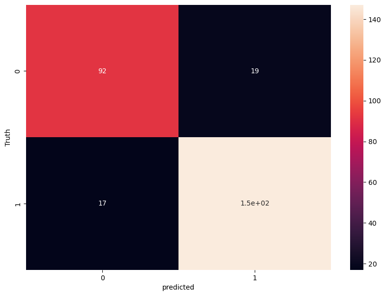

```python
# heat map
plt.figure(figsize=(10,7))
sns.heatmap(cm,annot= True)
plt.xlabel("predicted")
plt.ylabel('Truth')
```

- Class 0: Absence of heart disease
- Class 1: Presence of heart disease
- True Negative (TN): 92 (Predicted: 0, Actual: 0) - Correctly predicted absence of heart disease.
- False Positive (FP): 19 (Predicted: 1, Actual: 0) - Incorrectly predicted presence of heart disease when it's absent.
- False Negative (FN): 17 (Predicted: 0, Actual: 1) - Incorrectly predicted absence of heart disease when it's present.
- True Positive (TP): 147 (Predicted: 1, Actual: 1) - Correctly predicted presence of heart disease.

```python
precision= precision_score(y_test,y_predict,average=None)
precision
```

```
array([0.8440367 , 0.88554217])
```

For class 0(Absence of heart disease), approximately 84.40% predicted as absence of heart disease are correct, while for class 1(Presence of heart disease), approximately 88.55% of instances predicted as presence of heart disease are correct.

```python
recall= recall_score(y_test,y_predict,average= None)
recall
```

```
array([0.82882883, 0.89634146])
```

For class 0, approximately 82.88% of instances of absence of heart disease are correctly identified, while for class 1, approximately 89.63% of instances of presence of heart disease are correctly identified.

```python
f1= f1_score(y_test,y_predict,average= None)
f1
```

```
array([0.83636364, 0.89090909])
```

- F1 score for class 0 (absence of heart disease): 0.83636364
- F1 score for class 1 (presence of heart disease): 0.89090909